# CRISPRi library V2, data processing pipeline

# 1 Description

This R notebook details the data processing and visualization for growth competition experiments with a CRISPRi sgRNA library. The library contains around 20,000 unique sgRNA repression mutants tailored for the cyanobacterium *Synechocystis* sp. PCC6803. This library is the second version (therefore “V2”) of an sgRNA library for *Synechocystis*, containing 5 instead of only 2 sgRNAs per gene if possible. Some genes or ncRNAs are very short and hence it was no possible to design the maximum number of individual sgRNAs. The first iteration of the library was [published in Nature Communications, 2020](https://www.nature.com/articles/s41467-020-15491-7).

# 2 Quality control

## 2.1 Data import

Load required packages.

```r
library(tidyverse)
```

Load raw data. The main table contains already normalized quantification of all sgRNAs, fold change, multiple hypothesis corrected p-values, and fitness score. Contrary to the processing of [our first CRISPRi library V1](https://github.com/m-jahn/R-notebooks), much of the functionality from the notebook was transferred into the [new CRISPRi library pipeline on github](https://github.com/m-jahn/CRISPRi-lib-pipe).

```r
load("../data/input/DESeq2_result.Rdata", )
df_main <- DESeq_result_table; rm(DESeq_result_table)
```

Make a custom theme that is reused for all later plots.

```r
custom_colors = c("#E7298A", "#66A61E", "#E6AB02", "#7570B3", "#666666", "#1B9E77", "#D95F02", "#A6761D")
custom_theme <- function(base_size = 12, base_line_size = 1.0, base_rect_size = 1.0) {
  theme_light(base_size = base_size, base_line_size = base_line_size, base_rect_size = base_rect_size) + theme(
    plot.margin = unit(c(12,12,12,12), "points"),
    axis.ticks.length = unit(0.25, "cm"),
    axis.ticks = element_line(colour = "black", linetype = "solid", lineend = "round"),
    axis.text.x = element_text(colour = "black", size = 10),
    axis.text.y = element_text(colour = "black", size = 10),
    panel.grid.major = element_line(size = 0.8, linetype = "solid", colour = "#cacaca8F"),
    panel.grid.minor = element_line(size = 0.8, linetype = "solid", colour = "#cacaca8F"),
    panel.border = element_rect(linetype = "solid", colour = "black", fill = NA, size = 1.0),
    strip.background = element_rect(fill = grey(0.85), colour = "black"),
    strip.text = element_text(colour = "black", size = 10),
    panel.background = element_blank()
  )
}
```

## 2.2 Data annotation

Different annotation columns are added to the main data frame, including a short sgRNA identifier (excluding the position on the gene), an sgRNA index (1 to 5), and genome annotation from Uniprot. Note: The Uniprot data can also be dynamically downloaded for every update of this pipeline using their very simple API: `read_tsv("https://www.uniprot.org/uniprot/?query=taxonomy:1111708&format=tab")`.

```r
df_main <- df_main %>%
  # correct an error in sgRNA naming
  mutate(sgRNA = gsub('”', '2', sgRNA)) %>%
  # split sgRNA names into target gene and position
  separate(sgRNA, into = c("sgRNA_target", "sgRNA_position"), sep = "\\|",
    remove = FALSE) %>%

  # add sgRNA index number (1 to maximally 5) and type
  group_by(sgRNA_target) %>%
  mutate(
    sgRNA_index = sgRNA_position %>% as.numeric %>% as.factor %>%
    as.numeric,
    sgRNA_type = if_else(grepl("^nc_", sgRNA), "ncRNA", "gene")) %>%

  # map trivial names to LocusTags using a manually curated list
  left_join(
    read_tsv("../data/input/mapping_trivial_names.tsv", col_types = cols()),
    by = c("sgRNA_target" = "gene")) %>%

  # one more join, this time with the annotation db
  # containing uniprot and categorial (KEGG Brite) data
  left_join(read_csv("../../sgRNA_library/raw_data/Synechocystis_PCC6803_genome_annotation_20190614.csv")[c(1,4:6,11,20,22,27:32)],
    by = c("locus" = "GeneID"))

head(df_main)
```

| sgRNA | sgRNA_target | sgRNA_position | condition | date | time | group | reference_group | baseMean | log2FoldChange | lfcSE | stat | pvalue | padj | fitness | sgRNA_index | sgRNA_type | locus | Process | Pathway | Protein | Gene.names | Gene.ontology.IDs | Length | MolWeight | Process.abbr | Pathway.abbr | location | start_bp | end_bp |
| --- | --- | --- | --- | --- | --- | --- | --- | --- | --- | --- | --- | --- | --- | --- | --- | --- | --- | --- | --- | --- | --- | --- | --- | --- | --- | --- | --- | --- | --- |
| aat\|111 | aat | 111 | 1% CO2, BG11, 1000uE | 2021_02_07 | 0 | 23 | 23 | NA | 0.00000000 | 0.0000000 | NA | 1.0000000000 | 1.000000000 | -0.33431583 | 4 | gene | sll0869 | Translation | Protein modification and translation factors | Leu/Phe-tRNA-protein transferase | aat sll0869 | GO:0005737; GO:0008914; GO:0030163 | 198 | 22.94 | Translat | Protein modificati | Chr | 1149471 | 1150067 |
| aat\|111 | aat | 111 | 1% CO2, BG11, 1000uE | 2021_02_09 | 4 | 24 | 23 | 285.7195 | -0.45016854 | 0.1226985 | -3.6688998 | 0.0002435965 | 0.004033474 | -0.33431583 | 4 | gene | sll0869 | Translation | Protein modification and translation factors | Leu/Phe-tRNA-protein transferase | aat sll0869 | GO:0005737; GO:0008914; GO:0030163 | 198 | 22.94 | Translat | Protein modificati | Chr | 1149471 | 1150067 |
| aat\|111 | aat | 111 | 1% CO2, BG11, 1000uE | 2021_02_11 | 8 | 25 | 23 | 285.7195 | -0.42418709 | 0.1275001 | -3.3269543 | 0.0008780076 | 0.004869564 | -0.33431583 | 4 | gene | sll0869 | Translation | Protein modification and translation factors | Leu/Phe-tRNA-protein transferase | aat sll0869 | GO:0005737; GO:0008914; GO:0030163 | 198 | 22.94 | Translat | Protein modificati | Chr | 1149471 | 1150067 |
| aat\|111 | aat | 111 | 1% CO2, BG11, 1000uE | 2021_02_12 | 10 | 26 | 23 | 285.7195 | -0.26992286 | 0.1336654 | -2.0193927 | 0.0434464244 | 0.094315091 | -0.33431583 | 4 | gene | sll0869 | Translation | Protein modification and translation factors | Leu/Phe-tRNA-protein transferase | aat sll0869 | GO:0005737; GO:0008914; GO:0030163 | 198 | 22.94 | Translat | Protein modificati | Chr | 1149471 | 1150067 |
| aat\|111 | aat | 111 | 1% CO2, BG11, 60uE | 2021_01_09 | 0 | 7 | 7 | NA | 0.00000000 | 0.0000000 | NA | 1.0000000000 | 1.000000000 | 0.05661612 | 4 | gene | sll0869 | Translation | Protein modification and translation factors | Leu/Phe-tRNA-protein transferase | aat sll0869 | GO:0005737; GO:0008914; GO:0030163 | 198 | 22.94 | Translat | Protein modificati | Chr | 1149471 | 1150067 |
| aat\|111 | aat | 111 | 1% CO2, BG11, 60uE | 2021_01_13 | 4 | 8 | 7 | 285.7195 | 0.03664301 | 0.1191447 | 0.3075505 | 0.7584243553 | 0.999947091 | 0.05661612 | 4 | gene | sll0869 | Translation | Protein modification and translation factors | Leu/Phe-tRNA-protein transferase | aat sll0869 | GO:0005737; GO:0008914; GO:0030163 | 198 | 22.94 | Translat | Protein modificati | Chr | 1149471 | 1150067 |

## 2.3 Covariation of sgRNAs

Each gene is represented by up to five sgRNAs. We can test if all or only some of the 5 sgRNAs are “behaving” in the same way in the same conditions, more mathematically speaking we can estimate the covariation. First let’s summarize how many genes have 5, 4, 3 sgRNAs and so on associated with them.

```r
# N unique sgRNAs in dataset
paste0("Number of unique sgRNAs: ", unique(df_main$sgRNA) %>% length)
```

```
[1] "Number of unique sgRNAs: 21706"
```

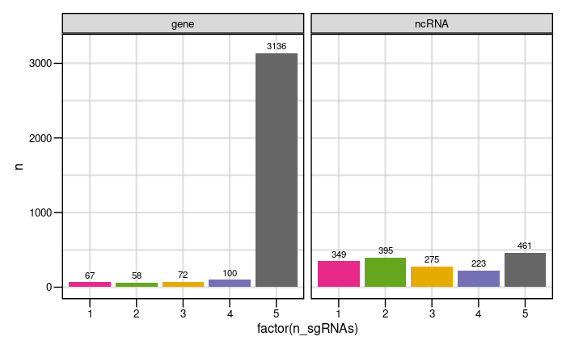

```r
# N genes with 1,2,3,4 or 5 sgRNAs
df_main %>%
  group_by(sgRNA_type, sgRNA_target) %>%
  summarize(n_sgRNAs = length(unique(sgRNA_position))) %>%
  count(n_sgRNAs) %>% filter(n_sgRNAs <= 5) %>%
  ggplot(aes(x = factor(n_sgRNAs), y = n, fill = factor(n_sgRNAs),
    label = n)) +
  geom_col(show.legend = FALSE) +
  geom_text(size = 3, nudge_y = 100) +
  facet_grid(~sgRNA_type) +
  custom_theme() +
  scale_fill_manual(values = custom_colors)
```